# H3 Grid System

# H3 Grid System

[output not shown]

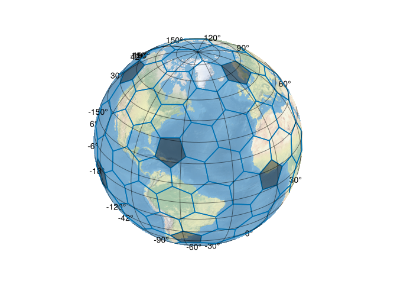

```julia
using GlobalGrids, GeoMakie, CairoMakie

grid = H3Grid()

fig = Figure()
ax = GeoAxis(fig[1,1], dest = "+proj=ortho +lon_0=-50 +lat_0=30")
lines!(ax, [grid[i] for i in 1:121])
poly!(ax, collect(GlobalGrids.pentagons(grid, 0)), color=(:black, .4))

ep = surface!(ax,
    -180..180, -90..90,
    zeros(axes(rotr90(GeoMakie.earth())));
    shading = NoShading, color = rotr90(GeoMakie.earth())
)
translate!(ep, 0, 0, -1)

fig
```

H3 is a DGGS developed by Uber. Here’s a brief summary of the H3 grid system:

- There are 16 resolutions (0-15 coarse-to-fine).
- At each resolution, there are exactly 12 pentagon cells in the grid. Every other cell is a hexagon.
- Pentagon locations are determined such that their centers are not on land.
- Refer to https://h3geo.org/docs for more information.

## Creating an `H3Cell`

- Every cell in the grid is indexed by a single `UInt64`. An `H3Cell` is simply a wrapper around a `UInt64` index.
- The index encodes the base cell (121 possible values, shown in the figure above), resolution, and *digits* (0-6).
- Each hexagon gets split into 7 hexagons by the next highest resolution. An additional digit corresponds to one of the smaller hexagons derived from its parent.

### From `H3Grid`

```julia
grid = H3Grid()

# Select one of the 121 base cells:
grid[121]
```

```
  ⬡ H3Cell 0 121-
```

```julia
# Nesting getindex to dive down the hierarchy:
grid[121][1][5][0]
```

```
  ⬡ H3Cell 3 121-150
```

### From Base Cell and Digits

```julia
H3Cell(121, [1, 5, 0])
```

```
  ⬡ H3Cell 3 121-150
```

### From Coordinates and Resolution:

```julia
coords = LonLat(-75.0, 54.0)

H3Cell(coords, 10)
```

```
  ⬡ H3Cell 10 7-1203346514
```

### From Hexadecimal String

```julia
c = H3Cell(coords)

str = GlobalGrids.h3_string(c)
@info str

H3Cell(str)
```

```
[ Info: 8a0e506e6a67fff
```

```
  ⬡ H3Cell 10 7-1203346514
```

## Inspecting H3Cells

```julia
@show resolution(c)
@show base_cell(c)
@show is_pentagon(c)
@show GlobalGrids.digits(c)
@show encode(c)
@show decode(c)
@show GlobalGrids.h3_face_numbers(c)
nothing
```

```
resolution(c) = 10
base_cell(c) = 7
is_pentagon(c) = false
GlobalGrids.digits(c) = [1, 2, 0, 3, 3, 4, 6, 5, 1, 4]
encode(c) = "8a0e506e6a67fff"
decode(c) = "7-1203346514"
GlobalGrids.h3_face_numbers(c) = Int32[2]
```

## GeoInterface Integration:

```julia
import GeoInterface as GI

@show GI.coordinates(c)
@show GI.centroid(c)
@show GI.area(c)  # meters ^ 2
nothing
```

```
GI.coordinates(c) = GlobalGrids.LonLat{Float64}[LonLat{Float64} (-74.99962251383738, 54.0001926668228), LonLat{Float64} (-75.0008585102879, 54.0000194052262), LonLat{Float64} (-75.00122192991167, 53.999307797036366), LonLat{Float64} (-75.00034938834023, 53.99876945809693), LonLat{Float64} (-74.99911…
GI.centroid(c) = LonLat{Float64} (-74.99998595778595, 53.99948106205936)
GI.area(c) = 17803.420253871413
```

## Grid Hierarchy

- `parent`, `siblings`, and `children`

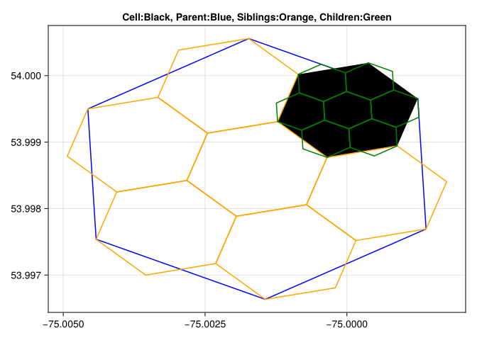

```julia
fig = Figure()
ax = Axis(fig[1,1], title="Cell:Black, Parent:Blue, Siblings:Orange, Children:Green")
lines!(ax, GlobalGrids.parent(c), color = :blue)
poly!(ax, c, color = :black)
lines!(ax, GlobalGrids.siblings(c), color = :orange)
lines!(ax, GlobalGrids.children(c), color = :green)
fig
```

## Rings and Disks

- `grid_ring(cell, i)` returns the cells that are exactly grid distance `i` away from the `cell`.
- `grid_disk(cell, i)` is similar to `grid_ring`, but returns all cells inside the ring as well.

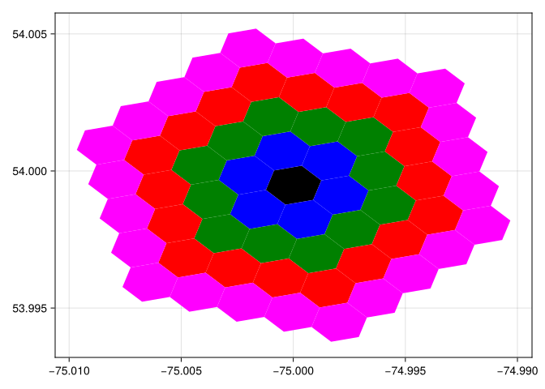

```julia
fig = Figure()
ax = Axis(fig[1,1])
colors = [:blue, :green, :red, :magenta]

poly!(ax, c, color=:black)
for i in 1:4
    poly!(ax, GlobalGrids.grid_ring(c, i), color=colors[i])
end


fig
```

## Quantizing Geometries to the H3 Grid

### Point

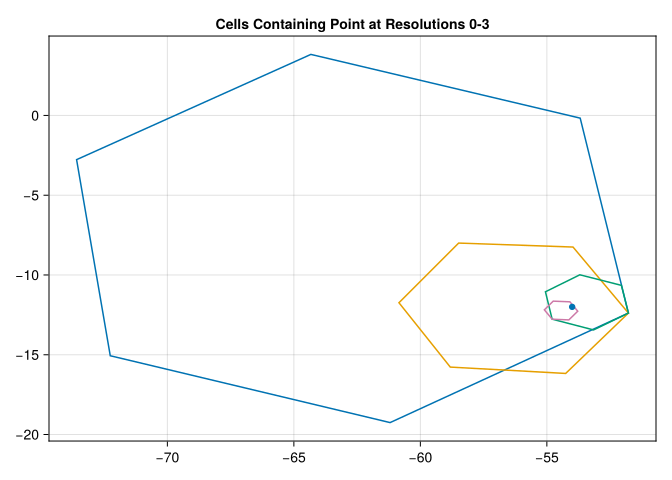

```julia
ll = LonLat(-54.0, -12.0)

fig = Figure()
ax = Axis(fig[1,1], title="Cells Containing Point at Resolutions 0-3")
for res in 0:3
    lines!(ax, h3cells(ll, res))
end
scatter!(ax, ll)

fig
```

### MultiPoint

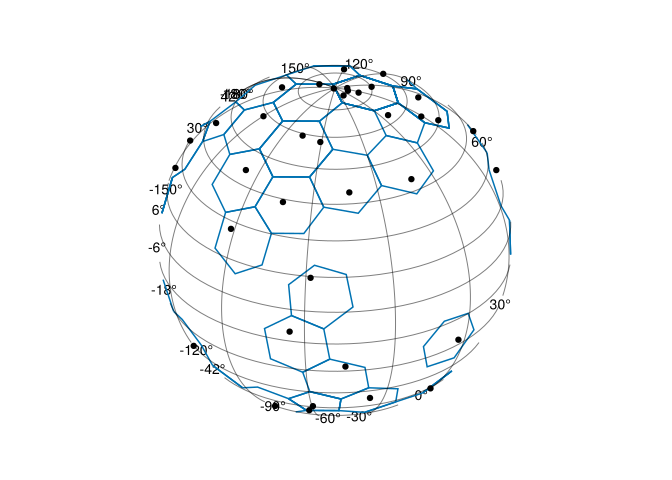

```julia
coords = [LonLat(360rand() - 180, 180rand() - 90) for _ in 1:100]

x = H3Cell.(coords, 0)

f, a, p = lines(x, axis=(;type=GeoAxis, dest = "+proj=ortho +lon_0=-50 +lat_0=30"))
scatter!(a, coords, color=:black)
f
```

### Line

- By default, the cells will be an arbitrary shortest path between the cells that contain the two points (`containment = :shortest_path`).
- The other containment options for line(string)s are `:overlap` and `:overlap_bbox`.

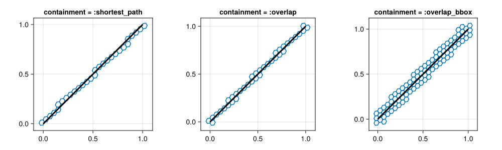

```julia
line = GI.Line([LonLat(0, 0), LonLat(1,1)])

fig = Figure(size=(1000, 300))

for (i, containment) in enumerate((:shortest_path, :overlap, :overlap_bbox))
    ax = Axis(fig[1, i], aspect=DataAspect(), title="containment = :$containment")
    x = h3cells(line, 6; containment)
    lines!(ax, x)
    lines!(ax, GI.coordinates(line), linewidth=3, color = :black)
end

fig
```

### (Multi)Polygon

- Containment modes for polygons:
  - `:center`: Include cell if its center is inside the polygon.
  - `:full`: Include cell if all vertices are inside the polygon.
  - `:overlap`: Include cell if any part intersects the polygon.
  - `:overlap_bbox`: Include cell if any part of the bounding box intersects the polygon.

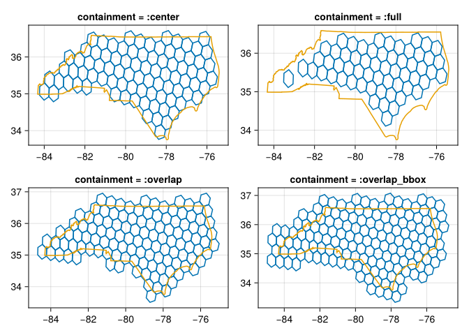

```julia
using OSMGeocoder

obj = geocode(state="North Carolina")

# Create figure
function make_axis(i, j, containment)
    ax = Axis(fig[i, j], title="containment = :$containment")
    x = h3cells(obj.geometry[1], 4; containment)
    lines!(ax, x)
    lines!(ax, obj.geometry)
end
fig = Figure()
make_axis(1, 1, :center)
make_axis(1, 2, :full)
make_axis(2, 1, :overlap)
make_axis(2, 2, :overlap_bbox)
fig
```

### Extents

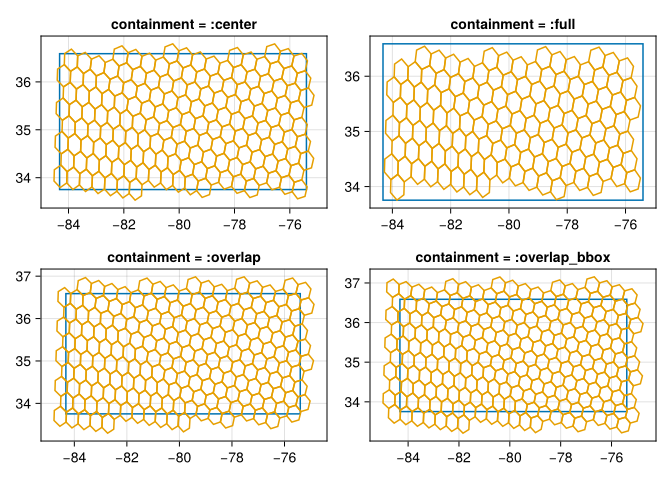

```julia
ex = GI.extent(obj)

# for plotting
x1, x2 = ex.X
y1, y2 = ex.Y
linestring = GI.LineString([(x1,y1), (x1,y2), (x2,y2), (x2, y1), (x1,y1)])

# Create figure
function make_axis(i, j, containment)
    ax = Axis(fig[i, j], title="containment = :$containment")
    x = h3cells(ex, 4; containment)
    lines!(ax, linestring)
    lines!(ax, x)
end
fig = Figure()
make_axis(1, 1, :center)
make_axis(1, 2, :full)
make_axis(2, 1, :overlap)
make_axis(2, 2, :overlap_bbox)
fig
```

## Quantizing Rasters

```julia
import Scratch
ENV["RASTERDATASOURCES_PATH"] = Scratch.get_scratch!("RASTERDATASOURCES_PATH")
nothing
```

[output not shown]

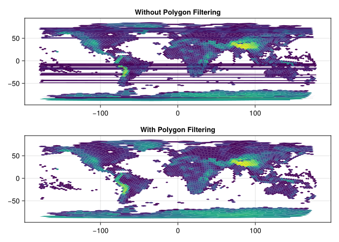

```julia
using GlobalGrids, Rasters, RasterDataSources, ArchGDAL

r = Raster(getraster(WorldClim{Elevation}).elev)

dict = h3cells(r, 2)

cells = collect(keys(dict))
vals = maximum.(values(dict))

# Do some work to avoid polygon issues on boundaries:
idx = findall(x -> !GlobalGrids.crosses_meridian(x, 180), cells)

cells2 = cells[idx]
vals2 = vals[idx]

fig = Figure()
ax1 = Axis(fig[1, 1], title="Without Polygon Filtering")
ax2 = Axis(fig[2, 1], title="With Polygon Filtering")

poly!(ax1, cells, color=vals)
poly!(ax2, cells2, color=vals2)
fig
```

**Note**

When plotting large numbers of cells, its more efficient to just plot the centroid of the cell:

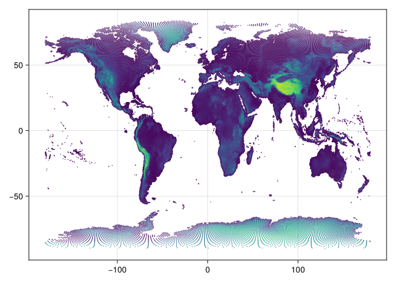

```julia
dict = h3cells(r, 4)

cells = collect(keys(dict))

vals = maximum.(values(dict))

scatter(GI.centroid.(cells), color=vals, markersize=2)
```